# Time Series Data and Forecast

Suphi Paşa

# What is done?

I used linear regression and ARIMA models to forecast data. Steps are reading and manipulating data, creating lm model, finding a stationary data for ARIMA and finally making the forecast.

## Data Manipulation

First, I manipulated data to fit my use. My data contained both train and test data.

```r
df <- read.csv("d.csv")
cons_data <- data.table(df)
setnames(cons_data, "Tüketim.Miktarý..MWh.","Tuketim")

cons_data[,Tarih:=as.Date(Tarih,format("%d.%m.%Y"))]
cons_data[,Saat:=as.numeric(gsub(":",".",Saat))]
cons_data[,Tuketim:=gsub("\\.", "", Tuketim)]
cons_data[,Tuketim:=as.numeric(gsub(",",".",Tuketim))]
```

Then, I added new columns for weekday, month, is.outlier and trend.Column is.outlier is a dummy variable indicating a special date. It is empty for now.

```r
cons_data[,month:=month(Tarih) ]
cons_data[,weekday:=weekdays(Tarih)]
cons_data[,is.outlier:=0]
cons_data[,trend:=1:.N]
```

## Building LM model

I created my first lm model to find residuals and special dates.

```r
model <- glm(Tuketim~-1+trend+weekday+is.outlier+as.factor(Saat)+as.factor(month), cons_data,
             family = "gaussian")
```

I added residual column and find determined quantile 2 is the special threshold.

```r
cons_data[,res:=residuals(model)]
quant2<-quantile(cons_data$res,0.02)
cons_data[res<quant2,is.outlier:=1]
```

Model again created but this time special days are regressors too. Residuals are updated.

```r
model <- glm(Tuketim~-1+trend+weekday+is.outlier+as.factor(Saat)+as.factor(month), cons_data,
             family = "gaussian")
summary(model)
```

```
##
## Call:
## glm(formula = Tuketim ~ -1 + trend + weekday + is.outlier + as.factor(Saat) +
##     as.factor(month), family = "gaussian", data = cons_data)
##
## Deviance Residuals:
##     Min       1Q   Median       3Q      Max
## -8009.0  -1307.2     77.8   1432.0   9103.5
##
## Coefficients:
##                      Estimate Std. Error  t value Pr(>|t|)
## trend               8.409e-03  1.142e-03    7.362 1.85e-13 ***
## weekdayFriday       3.405e+04  7.452e+01  456.956  < 2e-16 ***
## weekdayMonday       3.313e+04  7.441e+01  445.249  < 2e-16 ***
## weekdaySaturday     3.241e+04  7.461e+01  434.383  < 2e-16 ***
## weekdaySunday       2.900e+04  7.449e+01  389.264  < 2e-16 ***
## weekdayThursday     3.439e+04  7.444e+01  461.938  < 2e-16 ***
## weekdayTuesday      3.406e+04  7.433e+01  458.217  < 2e-16 ***
## weekdayWednesday    3.423e+04  7.435e+01  460.454  < 2e-16 ***
## is.outlier         -1.024e+04  8.375e+01 -122.219  < 2e-16 ***
## as.factor(Saat)1   -1.607e+03  7.975e+01  -20.155  < 2e-16 ***
## as.factor(Saat)2   -2.720e+03  7.975e+01  -34.103  < 2e-16 ***
## as.factor(Saat)3   -3.477e+03  7.975e+01  -43.599  < 2e-16 ***
## as.factor(Saat)4   -3.793e+03  7.975e+01  -47.566  < 2e-16 ***
## as.factor(Saat)5   -3.947e+03  7.975e+01  -49.493  < 2e-16 ***
## as.factor(Saat)6   -3.787e+03  7.975e+01  -47.490  < 2e-16 ***
## as.factor(Saat)7   -2.517e+03  7.976e+01  -31.564  < 2e-16 ***
## as.factor(Saat)8    1.087e+03  7.979e+01   13.628  < 2e-16 ***
## as.factor(Saat)9    3.230e+03  7.979e+01   40.484  < 2e-16 ***
## as.factor(Saat)10   3.914e+03  7.979e+01   49.056  < 2e-16 ***
## as.factor(Saat)11   4.443e+03  7.979e+01   55.689  < 2e-16 ***
## as.factor(Saat)12   3.257e+03  7.977e+01   40.823  < 2e-16 ***
## as.factor(Saat)13   3.637e+03  7.977e+01   45.586  < 2e-16 ***
## as.factor(Saat)14   4.427e+03  7.978e+01   55.489  < 2e-16 ***
## as.factor(Saat)15   4.397e+03  7.978e+01   55.111  < 2e-16 ***
## as.factor(Saat)16   4.685e+03  7.977e+01   58.728  < 2e-16 ***
## as.factor(Saat)17   4.953e+03  7.977e+01   62.097  < 2e-16 ***
## as.factor(Saat)18   4.982e+03  7.976e+01   62.468  < 2e-16 ***
## as.factor(Saat)19   5.033e+03  7.975e+01   63.105  < 2e-16 ***
## as.factor(Saat)20   4.857e+03  7.975e+01   60.898  < 2e-16 ***
```

[output cut: 9 more lines]

```
## as.factor(month)8   2.129e+03  5.403e+01   39.403  < 2e-16 ***
## as.factor(month)9  -5.030e+02  5.430e+01   -9.262  < 2e-16 ***
## as.factor(month)10 -3.765e+03  5.385e+01  -69.903  < 2e-16 ***
## as.factor(month)11 -2.035e+03  5.440e+01  -37.411  < 2e-16 ***
## as.factor(month)12 -3.688e+02  5.398e+01   -6.834 8.42e-12 ***
## ---
## Signif. codes:  0 '***' 0.001 '**' 0.01 '*' 0.05 '.' 0.1 ' ' 1
##
## (Dispersion parameter for gaussian family taken to be 4735312)
##
##     Null deviance: 4.0387e+13  on 35733  degrees of freedom
## Residual deviance: 1.6900e+11  on 35690  degrees of freedom
## AIC: 650687
##
## Number of Fisher Scoring iterations: 2
```

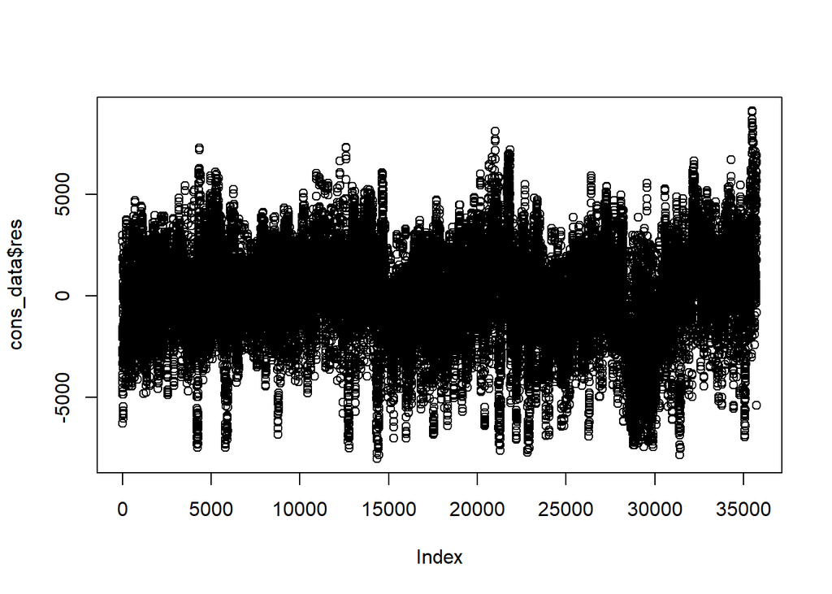

```r
cons_data[,res:=residuals(model)]
plot(cons_data$res)
```

I separated data to train and test data.tables and updated model with train data.

```r
train <- cons_data[Tarih<=as.Date("2021-01-08")]
test <- cons_data[Tarih<as.Date("2021-01-24")]
test <- test[Tarih>as.Date("2021-01-08")]
model <- glm(Tuketim~-1+trend+weekday+is.outlier+as.factor(Saat)+as.factor(month), train, family = "gaussian")
```

## Stationary data and ARIMA

I made a kpss test to see if series stationary. Value is too large, I created a differ row with 24Hour lag. This value is low enough to continue.

```r
unt_test <- ur.kpss(model$residuals)
summary(unt_test)
```

```
##
## #######################
## # KPSS Unit Root Test #
## #######################
##
## Test is of type: mu with 17 lags.
##
## Value of test-statistic is: 1.5824
##
## Critical value for a significance level of:
##                 10pct  5pct 2.5pct  1pct
## critical values 0.347 0.463  0.574 0.739
```

```r
train[,differ:=res-shift(res,24)]
unt_test <- ur.kpss(train$differ)
summary(unt_test)
```

```
##
## #######################
## # KPSS Unit Root Test #
## #######################
##
## Test is of type: mu with 17 lags.
##
## Value of test-statistic is: 0.0029
##
## Critical value for a significance level of:
##                 10pct  5pct 2.5pct  1pct
## critical values 0.347 0.463  0.574 0.739
```

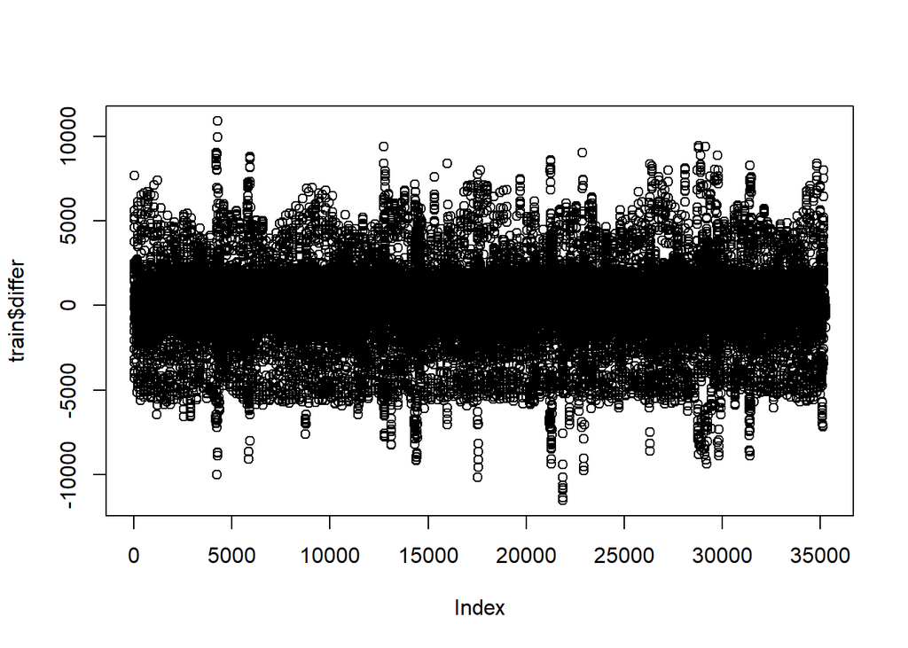

```r
plot(train$differ)
```

I built an Arima model with differ data.

```r
arima_model=auto.arima(train$differ,seasonal=F,trace=T)
```

```
##
##  Fitting models using approximations to speed things up...
##
##  ARIMA(2,0,2) with non-zero mean : 596247.9
##  ARIMA(0,0,0) with non-zero mean : 636683.5
##  ARIMA(1,0,0) with non-zero mean : 597384.2
##  ARIMA(0,0,1) with non-zero mean : 612885.4
##  ARIMA(0,0,0) with zero mean     : 636681.5
##  ARIMA(1,0,2) with non-zero mean : 596766
##  ARIMA(2,0,1) with non-zero mean : 596271
##  ARIMA(3,0,2) with non-zero mean : Inf
##  ARIMA(2,0,3) with non-zero mean : Inf
##  ARIMA(1,0,1) with non-zero mean : 596997
##  ARIMA(1,0,3) with non-zero mean : 596635.3
##  ARIMA(3,0,1) with non-zero mean : 596251.2
##  ARIMA(3,0,3) with non-zero mean : Inf
##  ARIMA(2,0,2) with zero mean     : 596245.9
##  ARIMA(1,0,2) with zero mean     : 596764
##  ARIMA(2,0,1) with zero mean     : 596269
##  ARIMA(3,0,2) with zero mean     : Inf
##  ARIMA(2,0,3) with zero mean     : Inf
##  ARIMA(1,0,1) with zero mean     : 596995
##  ARIMA(1,0,3) with zero mean     : 596633.3
##  ARIMA(3,0,1) with zero mean     : 596249.2
##  ARIMA(3,0,3) with zero mean     : Inf
##
##  Now re-fitting the best model(s) without approximations...
##
##  ARIMA(2,0,2) with zero mean     : 596249.6
##
##  Best model: ARIMA(2,0,2) with zero mean
```

```r
summary(arima_model)
```

```
## Series: train$differ
## ARIMA(2,0,2) with zero mean
##
## Coefficients:
##          ar1      ar2      ma1     ma2
##       1.5854  -0.6761  -0.6966  0.0348
## s.e.  0.0112   0.0089   0.0124  0.0068
##
## sigma^2 estimated as 1309876:  log likelihood=-298119.8
## AIC=596249.6   AICc=596249.6   BIC=596292
##
## Training set error measures:
##                     ME     RMSE      MAE      MPE     MAPE      MASE
## Training set 0.5976821 1144.433 528.7668 16.10896 373.4203 0.9988642
##                      ACF1
## Training set 0.0008296777
```

## Forecast

I get residual values of 08-01-2021 (last date) and repeated for lag residuals. Forecasted differ and Consumption values for test period. I added all data to test data.table

```r
nahead<-length(test$Tarih)
frc_differ<-forecast(arima_model,nahead)
frc_cons <- predict(model,test)
lag_res<-train[Tarih==as.Date("2021-01-08"),res]
test[,res:=rep(lag_res,15)]
test[,frc_cons:=frc_cons]
test[,frc_differ:=frc_differ$mean]
test[,forecast:=frc_cons+frc_differ+res]
```

Calculated error and daily MAPE,Bias and total WMAPE values

```r
test[,error:=Tuketim-forecast]
test[,MAPE:=sum(abs(error)/Tuketim)]
MAPE<-test[,sum(MAPE)/24,by=list(Tarih)]
Daily_bias<-test[,sum(error),by=list(Tarih)]
WMAPE<- sum(abs(test$error))/sum(test$Tuketim)
```

```r
MAPE
```

```
##          Tarih       V1
##  1: 2021-01-09 19.62091
##  2: 2021-01-10 19.62091
##  3: 2021-01-11 19.62091
##  4: 2021-01-12 19.62091
##  5: 2021-01-13 19.62091
##  6: 2021-01-14 19.62091
##  7: 2021-01-15 19.62091
##  8: 2021-01-16 19.62091
##  9: 2021-01-17 19.62091
## 10: 2021-01-18 19.62091
## 11: 2021-01-19 19.62091
## 12: 2021-01-20 19.62091
## 13: 2021-01-21 19.62091
## 14: 2021-01-22 19.62091
## 15: 2021-01-23 19.62091
```

```r
Daily_bias
```

```
##          Tarih        V1
##  1: 2021-01-09 -1202.196
##  2: 2021-01-10 10602.227
##  3: 2021-01-11 21854.939
##  4: 2021-01-12 10614.249
##  5: 2021-01-13 18785.774
##  6: 2021-01-14 30656.244
##  7: 2021-01-15 41155.375
##  8: 2021-01-16 20388.876
##  9: 2021-01-17 27780.729
## 10: 2021-01-18 70238.618
## 11: 2021-01-19 78421.461
## 12: 2021-01-20 80000.505
## 13: 2021-01-21 72286.056
## 14: 2021-01-22 58727.047
## 15: 2021-01-23 19618.827
```

Daily Bias shows that my forecast is generally below than the actual data. This may happen because probably I did not get rid of special day effect enough.

```r
WMAPE
```

```
## [1] 0.05610216
```

WMAPE is 0.056 and with no external data (temperature) I believe it is good enough. Having no special day in the test period helped this.